# Module. Questions

Oleksii Ignatenko

November 23, 2016

# Data manipulations

## Passenger Miles on Commercial US Airlines, 1937–1960

### Description

The revenue passenger miles flown by commercial airlines in the United States for each year from 1937 to 1960.

### Usage

airmiles

## **Task**

1. Create vector for miles from 1950 to 1955 (included) and calculate mean.
2. Calculate sum of all odd years
3. Summarise all miles per periods: 1937 - 1940, 1941-1950, 1951 - 1960
4. Calculate difference between summarised miles per periods 1941-1950, 1951 - 1960

## Monthly Airline Passenger Numbers 1949-1960

### Description

The classic Box & Jenkins airline data. Monthly totals of international airline passengers, 1949 to 1960.

### Usage

AirPassengers

### Format

A monthly time series, in thousands.

## **Task**

5. Create vector for May passengers and calculate its mean
6. What month gives the biggest sum of passengers? Define function to calculate sum for arbitrary month. Find the maximum sum.
7. What year gives the biggest mean of passengers? Define function to calculate mean for arbitrary year. Find the maximum mean.

## New York Air Quality Measurements

### Description

Daily air quality measurements in New York, May to September 1973.

### Usage

airquality

### Format

A data frame with 154 observations on 6 variables.

### Details

Daily readings of the following air quality values for May 1, 1973 (a Tuesday) to September 30, 1973.

Ozone: Mean ozone in parts per billion from 1300 to 1500 hours at Roosevelt Island

Solar.R: Solar radiation in Langleys in the frequency band 4000–7700 Angstroms from 0800 to 1200 hours at Central Park

Wind: Average wind speed in miles per hour at 0700 and 1000 hours at LaGuardia Airport

Temp: Maximum daily temperature in degrees Fahrenheit at La Guardia Airport.

## **Task**

8. Calculate number of observation without (any) missing values (NA’s)
9. Create function which returns temperature for all n’s days of month (for example all temperatures for first days are 67, 78, 84, 81, 91)
10. Create data frame with temperature and ozon variables summarized by month excluding NA’s (Write code that creates such data frame)
11. Calculate mean of Solar radiation varable for 5th month
12. Create data frame with two columns: Ozone maximum values per month and monthes
13. Calculate number of days when Wind was bigger then median value
14. Calculate total number of observation with at least on NA value
15. Create data frame with 10 observation with lowest temperature
16. Convert airquality dataset to dataframe and add column - temperature in Celsius degrees, rounded to integer value
17. Convert airquality dataset to dataframe and add column using Month and Day - date in format “Year-Month-Day” (year is in dataset description)
18. Calculate number of observation where solar radiation was in 100 - 200 range and wind was less then 12.

## The Chatterjee–Price Attitude Data

### Description

From a survey of the clerical employees of a large financial organization, the data are aggregated from the questionnaires of the approximately 35 employees for each of 30 (randomly selected) departments. The numbers give the percent proportion of favourable responses to seven questions in each department.

### Usage

attitude

### Format

A data frame with 30 observations on 7 variables. The first column are the short names from the reference, the second one the variable names in the data frame

## **Task**

19. Create function which takes name of column as an argument and returns mean of values for this column
20. Calculate mean of all columns exept “rating”. Is it equal to value of “rating”?
21. Extract all observations where learning value is higher than privileges value and complaints value is bigger than 50.
22. How many unique values exist for each column. Create function to calculate.
23. Create data frame with persons who prefer privileges more than average (mean) level of privileges.
24. Create data frame with observations which are in top 25% values for learning or advance values

## Quarterly Time Series of the Number of Australian Residents

### Description

Numbers (in thousands) of Australian residents measured quarterly from March 1971 to March 1994. The object is of class “ts”.

### Usage

austres

## **Task**

25. Create data frame with two columns - date (year + quarter) and value (amount). Convert austres dataset into this data frame.
26. Create vector of values for 1 quarter of each year and calculate sum.
27. Calculate how many observations are in 1300 - 1500 range?
28. Round values to integer numbers. Create vector with unique values.
29. Create vector of sums per each 5 years and define data frame with two columns - first column - range of time (eg 1971-1975) and second - total number of residents.
30. Create data frame with year and max value (max amoung quarters for this year) for it. Add new column - percent comparing to first (1971) year and calculate this percent for each year.
31. Create data frame with year, max amd min value (max and min amoung quarters for this year) for it. Add new column - difference between max and min and calculate this value for each year.
32. Create data frame with year and average value (average amoung quarters for this year) for it. Add new column - percent comparing previous year and calculate this value for each year.

## Body Temperature Series of Two Beavers

### Description

Reynolds (1994) describes a small part of a study of the long-term temperature dynamics of beaver Castor canadensis in north-central Wisconsin. Body temperature was measured by telemetry every 10 minutes for four females, but data from a one period of less than a day for each of two animals is used there.

### Usage

beaver1 beaver2

### Format

The beaver1 data frame has 114 rows and 4 columns on body temperature measurements at 10 minute intervals.

The beaver2 data frame has 100 rows and 4 columns on body temperature measurements at 10 minute intervals.

The variables are as follows:

**day** Day of observation (in days since the beginning of 1990), December 12–13 (beaver1) and November 3–4 (beaver2).

**time** Time of observation, in the form 0330 for 3:30am

**temp** Measured body temperature in degrees Celsius.

**activ** Indicator of activity outside the retreat.

### Note

The observation at 22:20 is missing in beaver1.

## **Task**

33. For beaver1, beaver2 dataset. Create function to transform day and time into time from the first observation (in minutes) and apply it to beavers datasets.
34. For beaver1, beaver2 dataset. Calculate maximum temperature for active and passive state for each beaver and compare values.
35. For beaver1, beaver2 dataset. Calculate average temperature for active and passive state for each beaver per day.
36. For beaver1 dataset. Calculate average temperature per hour for each day. Find hour with the biggest difference.
37. For beaver1, beaver2 dataset. Consider hypothesis: “beaver temperature is always bigger when they active”. Prove or discard this hypothesis (create R function to calculate number of observations when it fails).
38. For beaver1, beaver2 dataset. Consider hypothesis: “beaver temperature is in average bigger when they active”. Prove or discard this hypothesis (create R function to calculate number of observations when it fails).
39. For beaver2 dataset. Calculate average temp (for all observations) and create data frame with all observations which are bigger than average.
40. For beaver1, beaver2 dataset. Calculate total amount of time (in minutes) of active state for each beaver.
41. For beaver1, beaver2 dataset. Calculate ratio of activity for each beaver (time in active state/ total time).
42. For beaver2. Create data frame with average temperature per hour. Calculate ratio to max column (current temperature/ max temperature)
43. For beaver1. Create data frame with average temperature per hour. Calculate ratio to previous column (current temperature/ previous observation temperature)
44. For beaver1, beaver2 dataset. Create data frame with columns - hour (from the 00:00), temperature of 1 beaver, temperature of 2 beaver, difference (temp1 - temp2).

# Visualization

## Old Faithful Geyser Data

### Description

Waiting time between eruptions and the duration of the eruption for the Old Faithful geyser in Yellowstone National Park, Wyoming, USA.

### Usage

faithful

### Format

A data frame with 272 observations on 2 variables.

[,1] eruptions numeric Eruption time in mins

[,2] waiting numeric Waiting time to next eruption (in mins)

## **Task. Write code to achieve the same graph**

**Hint** Use ggplot2 library

45. Write code to achieve the same graph

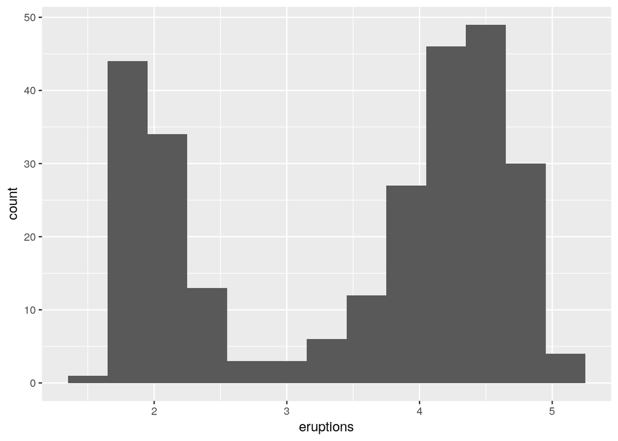

46. Write code to achieve the same graph

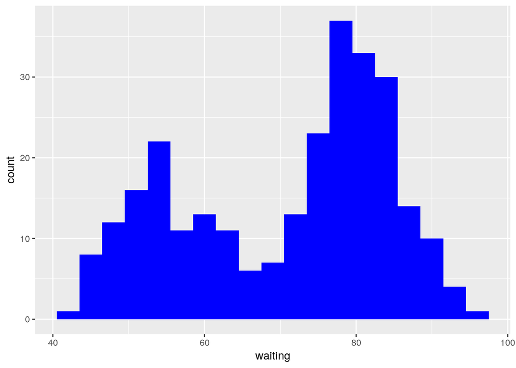

47. Write code to achieve the same graph

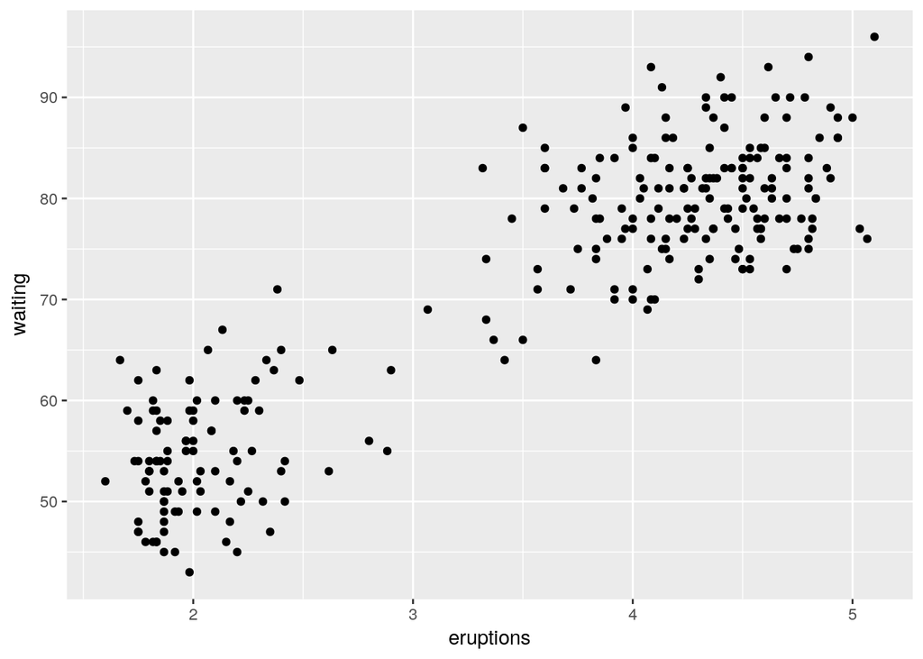

48. Write code to achieve the same graph

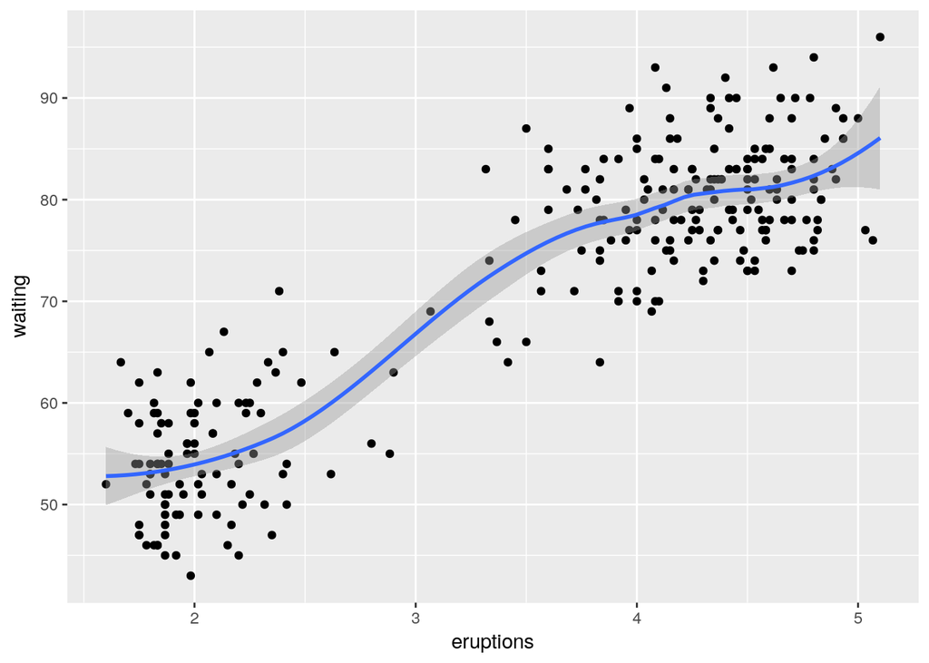

49. Write code to achieve the same graph

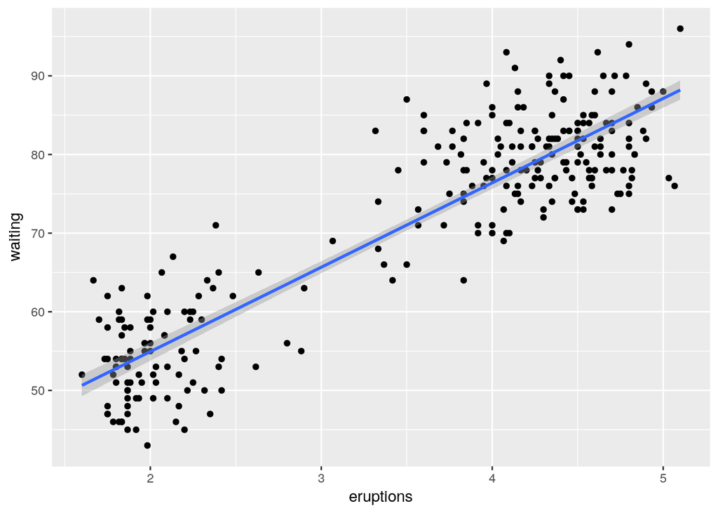

50. Write code to achieve the same graph

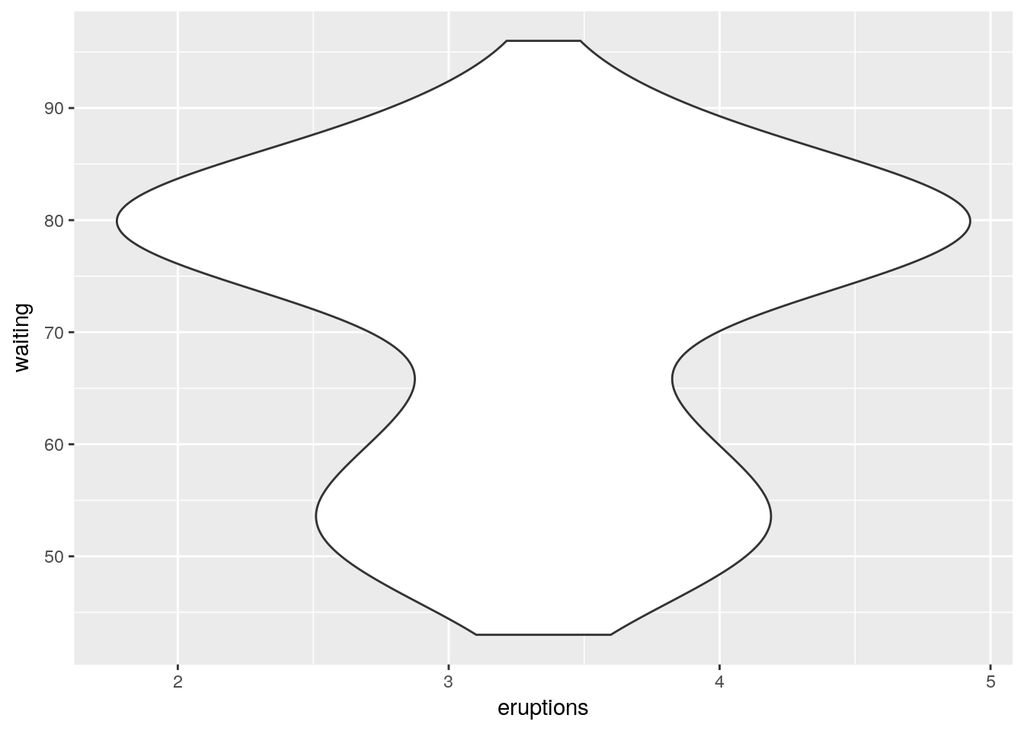

51. Write code to achieve the same graph

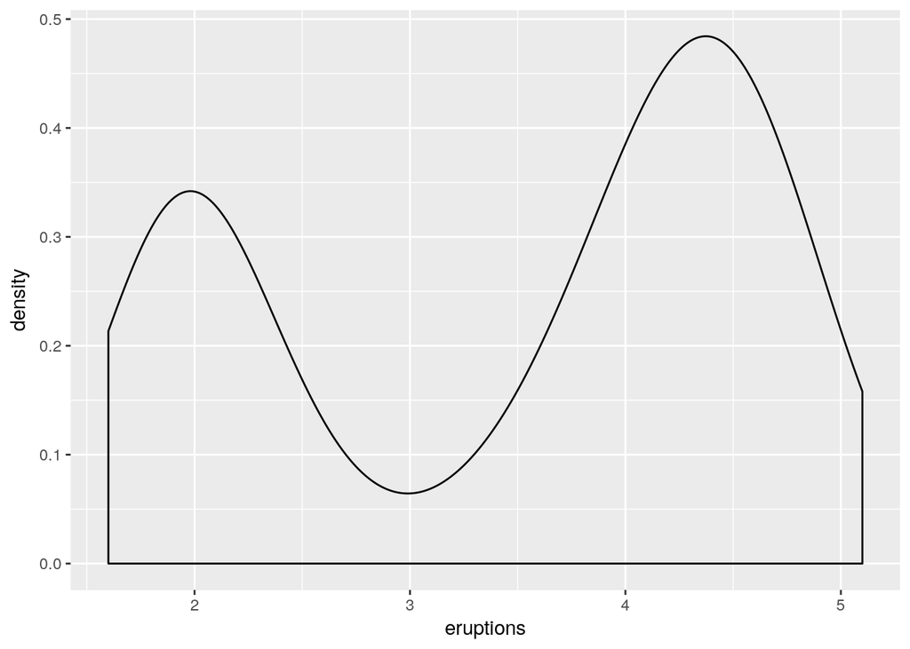

52. Write code to achieve the same graph

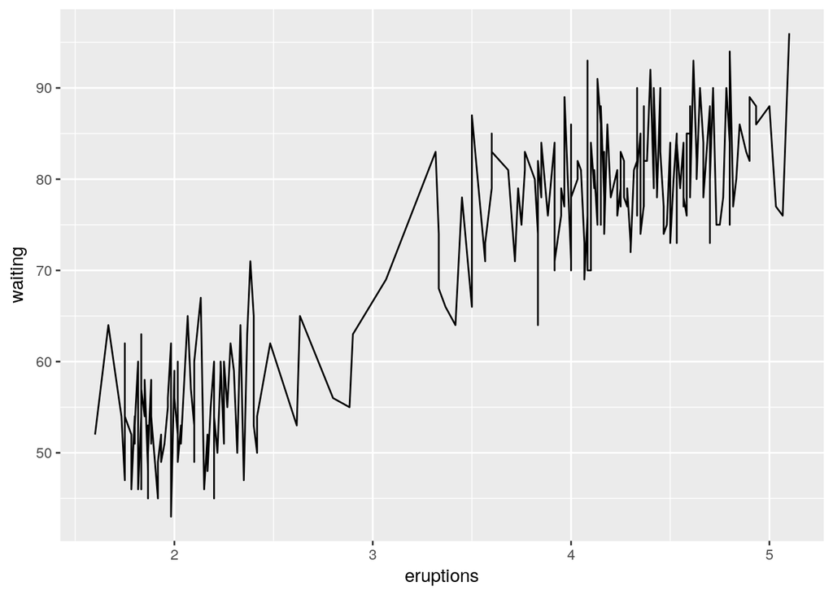

53. Write code to achieve the same graph

hint: check density 2d plot

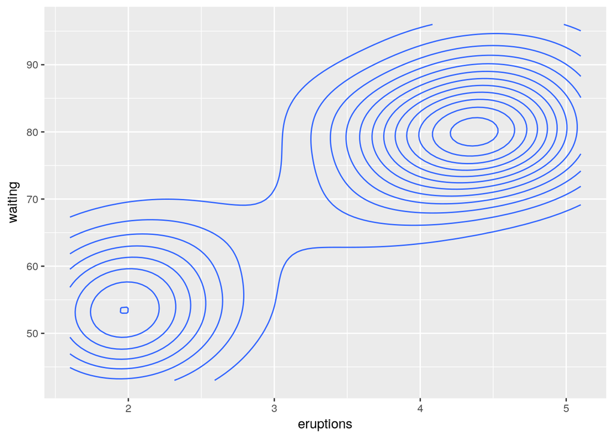

54. Write code to achieve the same graph

hint: check contour plot

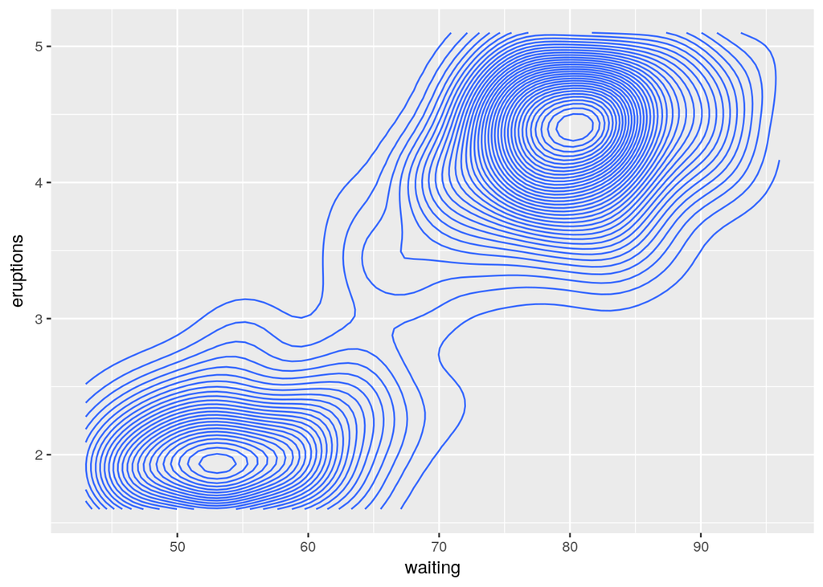

## Motor Trend Car Road Tests

### Description

The data was extracted from the 1974 Motor Trend US magazine, and comprises fuel consumption and 10 aspects of automobile design and performance for 32 automobiles (1973–74 models).

### Usage

mtcars

### Format

A data frame with 32 observations on 11 variables.

## **Task**

55. Write code to achieve the same graph

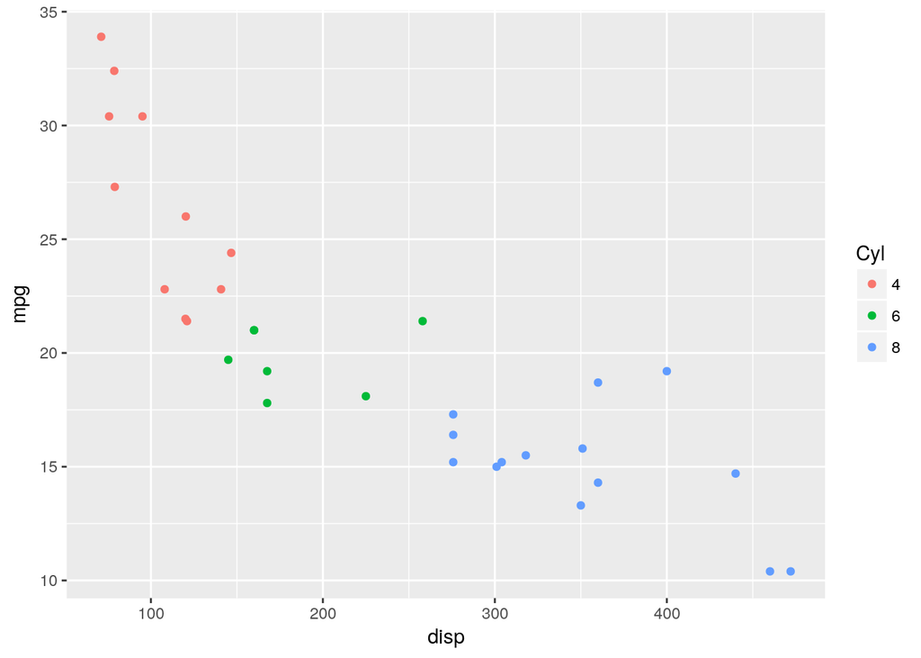

56. Write code to achieve the same graph

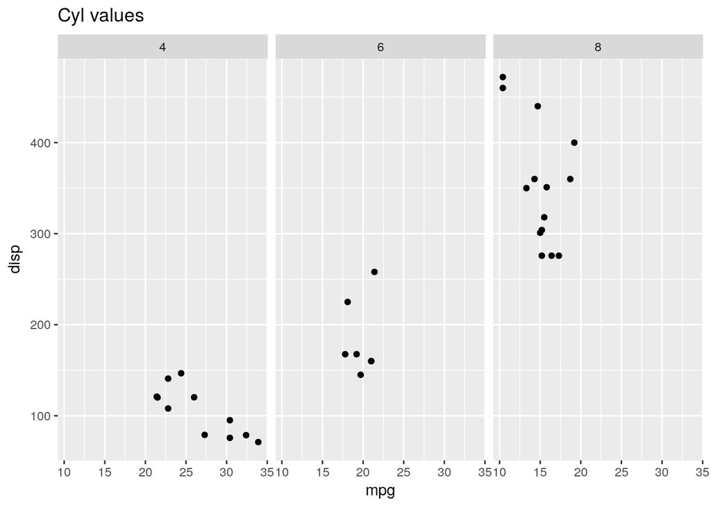

57. Write code to achieve the same graph

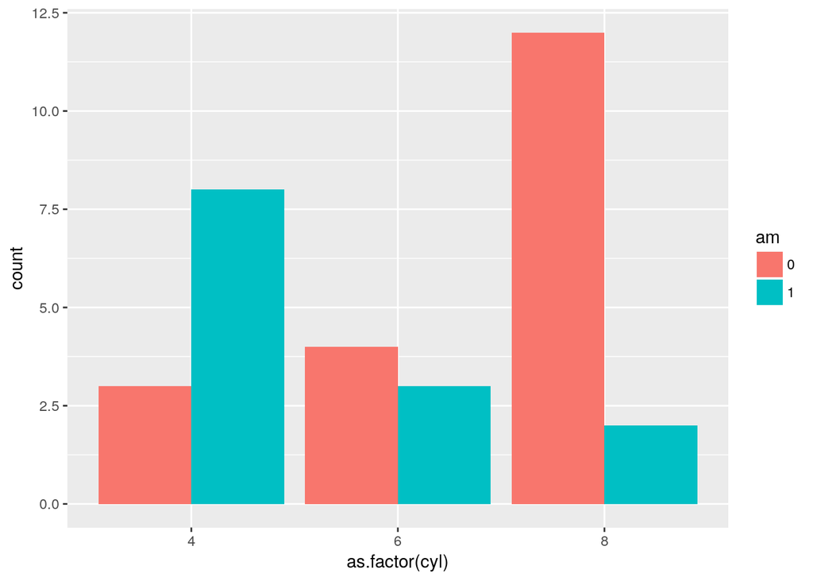

58. Write code to achieve the same graph

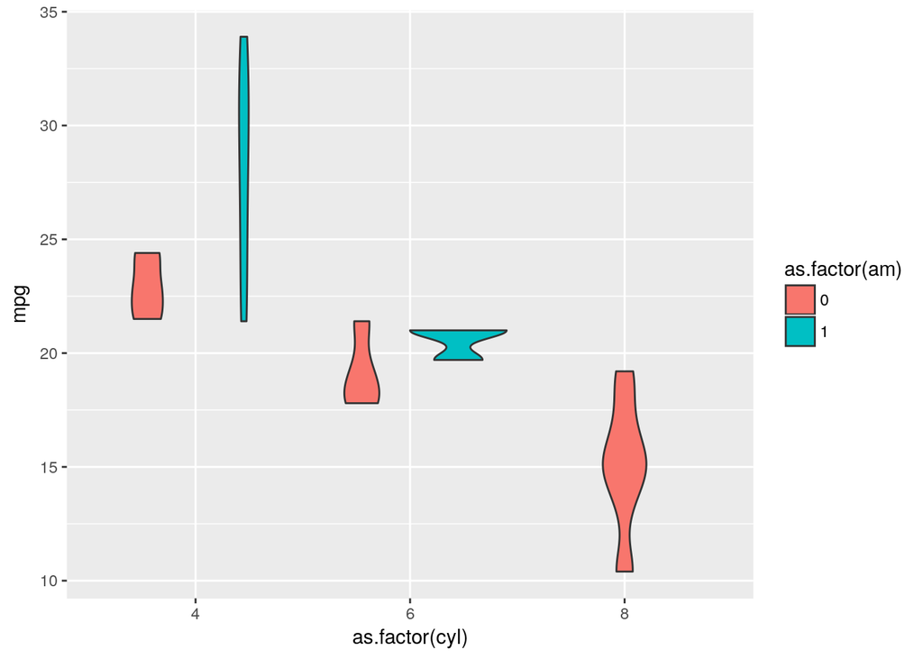

59. Write code to achieve the same graph

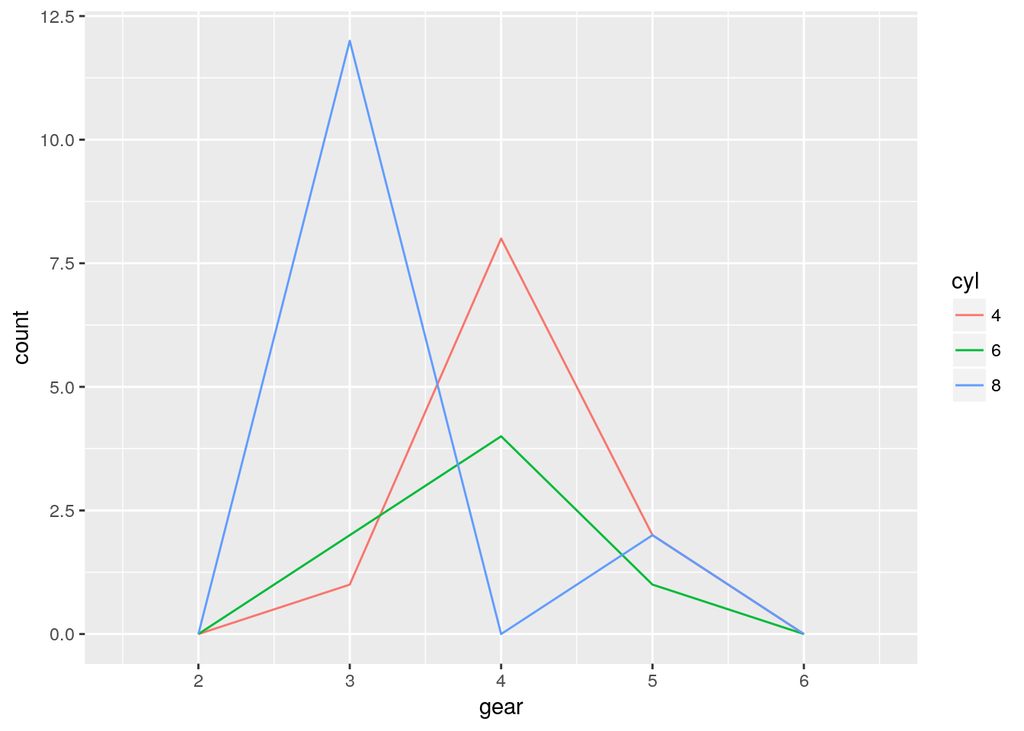

60. Write code to achieve the same graph

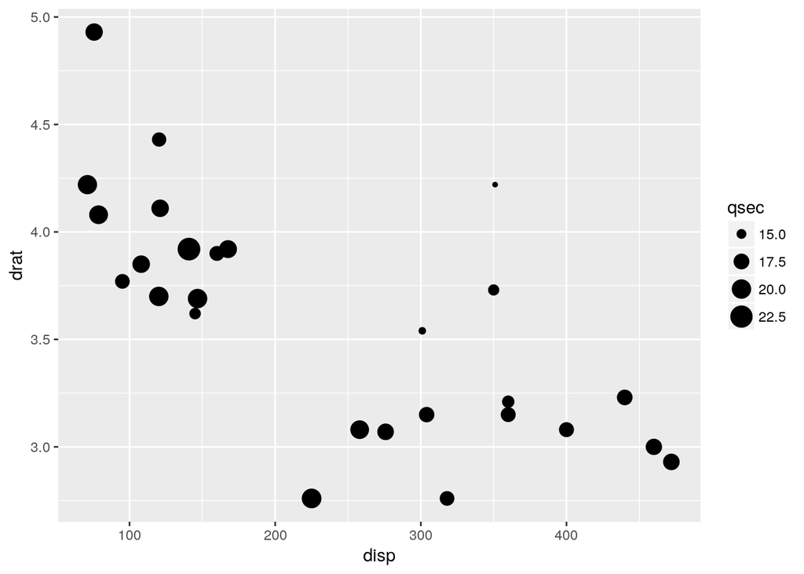

61. Write code to achieve the same graph

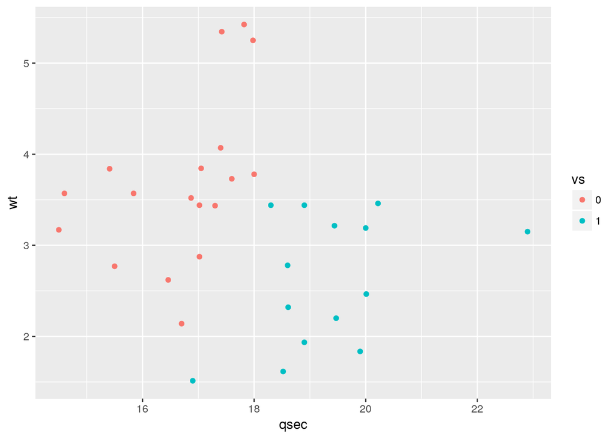

62. Write code to achieve the same graph

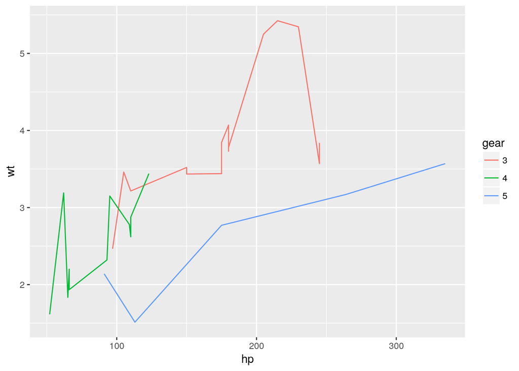

63. Write code to achieve the same graph

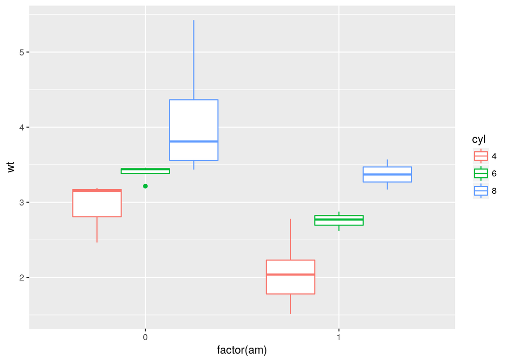

64. Write code to achieve the same graph

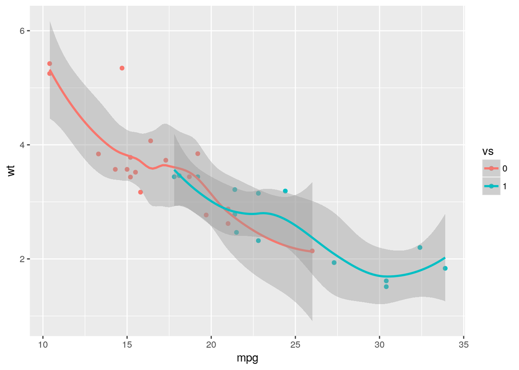

65. Write code to achieve the same graph

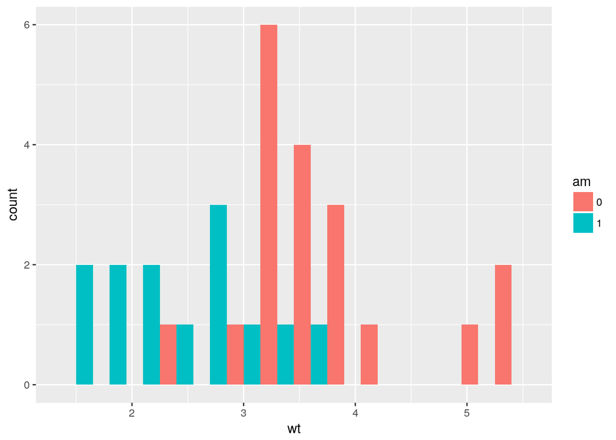

66. Write code to achieve the same graph

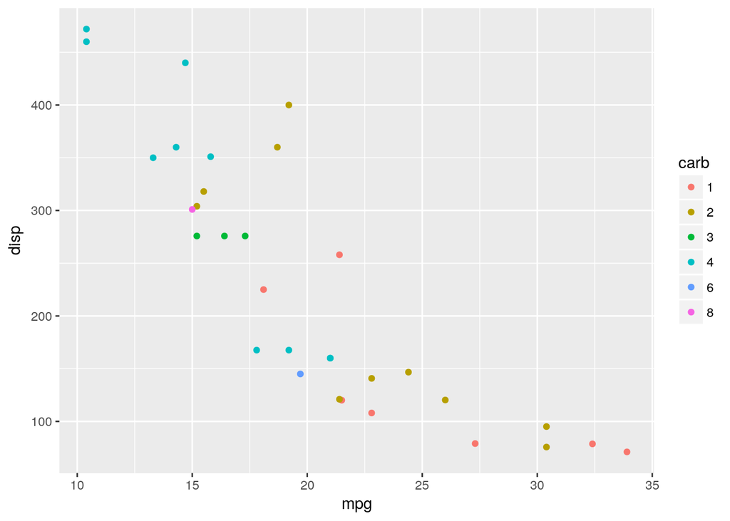

# General questions

67. The expression 2**4 returns:
    1. 2
    2. 24
    3. 16
    4. 24
68. We want to select two columns from a data frame called Clients, which expression is correct:
    1. Clients[1,2]
    2. Clients[c(1,2)]
    3. Clients[,c(1,2)]
    4. Clients[c(1,2),]
69. What is the value of the expression 2+NA
    1. NA
    2. Null
    3. 2
    4. 0
70. If you want to calculate mean for each level in a factor, you would use which function:
    1. apply
    2. tapply
    3. sapply
    4. lapply
71. We toss a fair coin 16 times, how to calculate probability of getting 7 or less tails
    1. rbinom(7,prob=0.5,size=16)
    2. dbinom(7,prob=0.5,size=16)
    3. qbinom(7,prob=0.5,size=16)
    4. pbinom(7,prob=0.5,size=16)
72. We want to compare two means, which is the best function to use:
    1. f.test
    2. aov
    3. t.test
    4. meantest
73. In order to add rows to a data frame which function is the most appropriate:
    1. addrows
    2. cbind
    3. rbind
    4. rowsadd
74. If you want to plot a bar chart, which function would you use:
    1. plot
    2. barchart
    3. barplot
    4. plotbar
75. Which of these options are NOT correct for the below R script?

```r
    B <- 9
    rm(B)
```

```
1. B is an object
2. B is removed
3. B is R Matrix
4. B is deleted from R environment
```

76. In one of the application, you wanted to generate odd integer numbers between 10 and 15, which of the below option could be used?
    1. rep
    2. seq
    3. All of the options
    4. colon (:)
77. Which of these options are correct for the below R script?

```r
    A <-100
    a
```

```
1. None of the options
2. It prints 6
3. It gives an error
4. It shows missing value
```

78. Which of these options is correct assignment statement?
    1. C <- 6
    2. A=7
    3. All Options
    4. D <- 5+7
79. Which of the below are INCORRECT example of R data type?
    1. Logical
    2. String
    3. Complex
    4. Integer
80. Which of the following statements in R are “legal” (i.e., will not generate an error, suppose x,y,z are defined objects in R environment)
    1. 1 = 2
    2. help(“t.test)”
    3. z = x > y
    4. x == x
81. What is the “working directory” in R?
    1. The directory that the R interpreter is currently “looking at”. Filenames are relative to this folder
    2. The place with R’s configuration files are stored
    3. The place with files must be saved in order to be used with R
82. How do you check the current working directory that R is using
    1. dir()
    2. help(dir)
    3. getwd()
    4. workingdir()
83. Use the following code to create the data frame:

```r
admissions <- data.frame(1:4,c("al","ab","sr","ty"),rep(date()),c(1,2,3,4))
names(admissions)<-c("id","name","date","Freq")
```

How do you change the column name “Freq” to “Frequency”? (Choose all that apply)

```
1. names(admissions)[names(admissions) == "Freq"] <- "Frequency"
2. colnames(admissions)[4] <- "Frequency"
3. names(admissions)[which(names(admissions) == "Freq")] <- "Frequency"
4. All the above
```

84. Use the following code to create the data frame:

```r
admissions <- data.frame(1:4,c("al","ab","sr","ty"),rep(date()),c(1,2,3,4))
names(admissions)<-c("id","name","date","Freq")
```

Which statements are true about the below command? (Choose all that apply)

```r
data <- data.frame(admissions[which(admissions$Freq > 2), ])
```

```
1. It creates a new dataframe by the name "data"
2. The new dataframe has 3 observations
3. The new dataframe has observations with Frequency less that 3
4. All the statements are true
```

85. What function do you use to sort a dataframe in R ? (Choose all that apply)
    1. order()
    2. sort()
    3. reorder()
    4. arrange()
86. In the data “Dept” column takes following value “A, B, C, D, E, F”. You are required to create a column which group “A”,“C”,“F” into one level and other into different level for the new column.

Which of the function can help you do that?

```
1. if statement
2. for loop
3. if else statement
4. ifelse function
```

87. Which of the following is an example of a valid graphics device in R?
    1. A socket connection
    2. A Microsoft Word document
    3. A PDF file
    4. A file folder
88. If you explicitly want an integer, you need to specify the _____ suffix.
    1. D
    2. R
    3. L
    4. All of the mentioned